# Esercizi Modulo 3

Soluzuioni seconda parte - Variabili quantitative e categoriali

Autore/Autrice

Ottavia M. Epifania

# 1 Introduzione

Questa nuova serie di esercizi sul terzo modulo didattico sono divisi in due parti: 1) esercizi sulla regressione lineare 2) esercizi sulla statistica Chi quadrato.

Queste variabili sono ricavate dal famoso esempio di Anscombe (1973, Graphs in statistical analysis, The American Statistician).

```r
X1 <- c(10,8,13,9,11,14,6,4,12,7,5)
Y1 <- c(8.04,6.95,7.58,8.81,8.33,9.96,7.24,4.26,10.84,4.82,5.68)
Y2 <- c(9.14,8.14,8.74,8.77,9.26,8.10,6.13,3.10,9.13,7.26,4.74)
Y3 <- c(7.46,6.77,12.74,7.11,7.81,8.84,6.08,5.39,8.15,6.42,5.73)
X2 <- c(8,8,8,8,8,8,8,19,8,8,8)
Y4 <- c(6.58,5.76,7.71,8.84,8.47,7.04,5.25,12.50,5.56,7.91,6.89)
```

# 2 Esercizio 1

## 2.1

studiare la relazione tra le seguenti coppie di variabili attraverso dei modelli di regressione. Visualizzare graficamente la relazione tra le varaibili attraverso un grafico a disperisione: - $(X1,Y1)$ (modello di regressione `MR1`) - $(X1,Y2)$ (modello di regressione `MR2`) - $(X1,Y3)$ (modello di regressione `MR3`) - $(X2,Y4)$ (modello di regressione `MR4`)

[figure not shown]

```r
par(mfrow=c(2,2))



plot(X1,Y1, main = "X1,Y1")

MR1 <- lm(Y1 ~ X1)

abline(MR1)



plot(X1,Y2)

MR2 <- lm(Y2 ~ X1, main = "X1,Y2")

abline(MR2)



plot(X1,Y3, main = "X1,Y3")

MR3 <- lm(Y3 ~ X1)

abline(MR3)



plot(X2,Y4, main = "X2,Y4")

MR4 <- lm(Y4 ~ X2)

abline(MR4)
```

## 2.2

Studia la relazione tra la variabile indipendente ed i residui per ciascun modello utilizzando dei grafici di dispersione. Che tipo di commenti puoi fare circa ciascun grafico di dispersione?

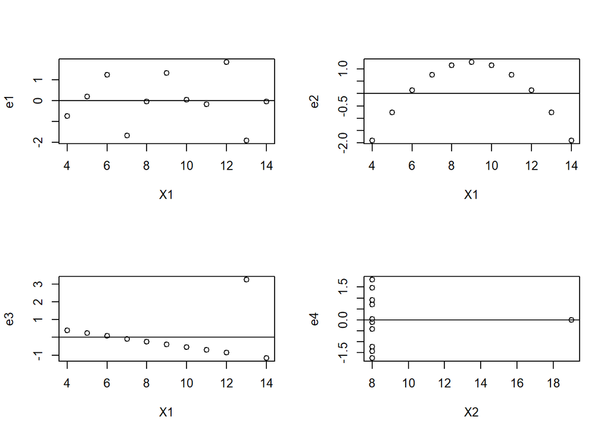

```r
# calcolo dei residui per tutti i modelli con la funzione residulas()
e1 = residuals(MR1)
e2 = residuals(MR2)
e3 = residuals(MR3)
e4 = residuals(MR4)

par(mfrow = c(2,2))
plot(X1,e1)
abline(0,0)

plot(X1,e2)
abline(0,0)

plot(X1,e3)
abline(0,0)

plot(X2,e4)
abline(0,0)
```

## 2.3

Calcola e visualizza la percentuale di varianza spiegata per ciascun modello

```r
R2MR1 <- 1-(var(e1)/var(Y1))
# R2MR1 <- cor(X1,Y1)^2 # alternativa di calcolo
# R2MR1 <- summary(MR1)$r.squared # alternativa di calcolo
R2MR1
```

```
[1] 0.6665425
```

```r
R2MR2 <- 1-(var(e2)/var(Y2))
# R2MR2 <- cor(X1,Y2)^2 # alternativa di calcolo
# R2MR2 <- summary(MR2)$r.squared # alternativa di calcolo
R2MR2
```

```
[1] 0.666242
```

```r
R2MR3 <- 1-(var(e3)/var(Y3))
# R2MR3 <- cor(X1,Y3)^2 # alternativa di calcolo
# R2MR3 <- summary(MR3)$r.squared # alternativa di calcolo
R2MR3
```

```
[1] 0.666324
```

```r
R2MR4 <- 1-(var(e4)/var(Y4))
# R2MR4 <- cor(X2,Y4)^2 # alternativa di calcolo
# R2MR4 <- summary(MR4)$r.squared # alternativa di calcolo
R2MR4
```

```
[1] 0.6667073
```

## 2.4

Calcola i valori predetti dal primo modello di regressione (`MR1`) per $X1 = \{-25, 0.25, 44.9, 100.8\}$

```r
predict(MR1,data.frame(X1=c(-25,0.25,44.9,100.8)))
```

```
        1         2         3         4
-9.502182  3.125114 25.454173 53.409255
```

```r
# usando l'equazione della retta
coef(MR1)[1] + coef(MR1)[2]*c(-25,0.25,44.9,100.8)
```

```
[1] -9.502182  3.125114 25.454173 53.409255
```

## 2.5 Esercizio 2

## 2.6

Si consideri la seguente coppia di variabili categoriali `A` e `B` con rispettivamente 3 e 2 livelli:

A=(a1,a2,a2,a1,a3,a3,a3,a1,a2,a1,a2,a1,a3,a2,a2,a1,a3,a2,a1)

B=(b1,b1,b1,b1,b1,b1,b1,b1,b1,b2,b2,b2,b2,b2,b2,b2,b2,b2,b2)

Si costruisca la tabella di contingenza `f_o` associata alle due variabili A e B.

```r
A <- factor(c("a1","a2","a2","a1","a3","a3","a3","a1","a2","a1","a2","a1","a3","a2","a2","a1","a3","a2","a1"))
B <- factor(c(rep("b1",9),rep("b2",10)))
f_o <- table(A,B)
f_o
```

```
    B
A    b1 b2
  a1  3  4
  a2  3  4
  a3  3  2
```

## 2.7

Costruire la tabella di contingenza, `f_t`, che contenga le frequenze teoriche associate al modello di indipendenza tra `A` e `B`.

```r
mA <- margin.table(f_o,1) # marginali di riga
mB <- margin.table(f_o,2) # marginali di colonna
n <- sum(f_o) # totale osservazioni

f_t = matrix(nrow = 3, ncol = 2) # crea una matrice vuota da "riempire" con le frequenze teoriche

f_t[1,1] <- (mA[1]*mB[1])/n

f_t[1,2] <- (mA[1]*mB[2])/n

f_t[2,1] <- (mA[2]*mB[1])/n

f_t[2,2] <- (mA[2]*mB[2])/n

f_t[3,1] <- (mA[3]*mB[1])/n

f_t[3,2] <- (mA[2]*mB[1])/n
f_t
```

```
         [,1]     [,2]
[1,] 3.315789 3.684211
[2,] 3.315789 3.684211
[3,] 2.368421 3.315789
```

```r
rownames(f_t) <- c("a1","a2","a3")
colnames(f_t) <- c("b1","b2")

# soluzione con ciclo for, solo se avete idea di come funzioni
# for(i in 1:nrow(f_t)) {
#   for (j in 1:ncol(f_o)) {
#     f_t[i, j] = (mA[i]*mB[j])/n
#   }
# }
```

## 2.8

Calcola e visualizza il valore del Chi-quadrato osservato ottenuto sulla tabella di contingenza `f_o`.

```r
chisq.test(f_o)$statistic
```

```
X-squared
0.4342857
```

## 2.9

Calcola l’indice normalizzato del Chi-quadrato osservato:

$$\chi_N^2 = \dfrac{\chi^2}{N\times \min[(r-1); (c-1)]}$$

Quale conclusione si può trarre dal risultato di tale indice?

```r
MaxChiQ <- n*min(dim(f_o)[1]-1,dim(f_o)[2]-1)

ChiQOss <- chisq.test(f_o)$statistic

ChiQNorm <- ChiQOss/MaxChiQ

ChiQNorm
```

```
 X-squared
0.02285714
```

## 2.10

Calcola il valore del Chi-quadrato osservato ottenuto sulla tabella di contingenza `f_o` limitata ai soli valori `a1` e `a3` della variabile categoriale A. Su questa nuova tabella di contingenza calcola l’indice normalizzato del Chi-quadrato.

```r
f_o1 <- f_o[c(1,3),]

MaxChiQ2 <- n*min(dim(f_o1)[1]-1,dim(f_o1)[2]-1)



ChiQOss2 <- chisq.test(f_o1)$statistic
ChiQNorm2 <- ChiQOss2/MaxChiQ2

ChiQNorm2
```

```
X-squared
        0
```

## 2.11

Costruisci una nuova tabella di contingenza sommando i valori della seconda e terza riga di `f_o`. Questa nuova tabella di contingenza esprime l’associazione tra i valori `b1` e `b2` della variabile categoriale `B` e i valori `a1` e ${a2,a3}$ della nuova variabile categoriale `A2`.

Per questa nuova tabella di contingenza:

- deriva la tabella di contingenza associata alle frequenze teoriche del modello di indipendenza tra `A2` e `B`
- visualizza il valore del Chi-quadrato osservato
- calcola il valore del Chi-quadrato normalizzato.

```r
A2 <- as.character(A)
A2[A2=="a2" | A2=="a3"] <- "a23"

f_o2 <- table(A2,B)

f_o2
```

```
     B
A2    b1 b2
  a1   3  4
  a23  6  6
```

```r
mA2 <- margin.table(f_o2,1)
mB <- margin.table(f_o2,2)
n <- sum(f_o2)



f_t2 <- matrix(rep(0,4),2,2)
for(i in 1:nrow(f_t2)) {
  for (j in 1:ncol(f_t2)) {
    f_t2[i, j] = (mA2[i]*mB[j])/n
  }
}

f_t2
```

```
         [,1]     [,2]
[1,] 3.315789 3.684211
[2,] 5.684211 6.315789
```

```r
MaxChiQ3 <- n*min(dim(f_o2)[1]-1,dim(f_o2)[2]-1)

ChiQOss3 <- chisq.test(f_o2)$statistic
ChiQNorm3 <- ChiQOss3/MaxChiQ3

ChiQNorm3
```

```
X-squared
        0
```